# RNASeq - Practical Session 1

7/24/2017

# Introduction

In this practical session of RNASeq analysis, we will go through the most basic steps to perform a differential expression analysis. There’s a huge plethora of upstream steps that can be performed in order to get to this point, these steps have already been discussed in the theoretical part of this course. Since we will be working with public data, our starting point will be a matrix composed of integer numbers, where, by row we have each of the mapped genes, and by column the samples.

In this practical session, the differential expression analysis will be performed using the [**DESeq2**](http://bioconductor.org/packages/release/bioc/html/DESeq2.html) package from [Love, *et al*](https://genomebiology.biomedcentral.com/articles/10.1186/s13059-014-0550-8). Yet other packages in R could also provide similar or comparable results such as: [edgeR](http://bioconductor.org/packages/release/bioc/html/edgeR.html) or [limma](https://bioconductor.org/packages/release/bioc/html/limma.html).

## Public data

There are several repositories from which we can browse and retrieve RNASeq and microarray based expression data. The most commonly used ones are:

- [GEO](https://www.ncbi.nlm.nih.gov/geo/)
- [ArrayExpress](https://www.ebi.ac.uk/arrayexpress/)
- [ENA](http://www.ebi.ac.uk/ena)

Both GEO and ArrayExpress and routinely synchronized with each other, and are the repositories were processed data can also be stored. On the other hand, ENA covers raw sequencing data, sequence assembly information and functional annotation, which could potentially be processed to generate gene counts.

### Case study

For this practical session we will make use of a dataset comprised of 74 transcriptome profiles of CD4+ T cells from celiac disease patients and healthy controls, which have also been subjected to two different immune stimulation with CD3 and PMA. You can find the dataset here: GSE69549. Or download it directly from [here](https://drive.google.com/file/d/0B7_V7DVS0TVMRWhLS3hpVmgySGM/view?usp=sharing). The article is from [Quinn et al. 2015](https://pubmed.ncbi.nlm.nih.gov/26444573/).

Q1: What is the transcriptome?

Q2: What is the difference between CD3 and PMA t-cell activation?

### Installing packages

```r
## Install packages from CRAN
install.packages("ggsci")
install.packages("ggplot2")
install.packages("gridExtra")
install.packages("ggrepel")
install.packages("RColorBrewer")
install.packages("pheatmap")
install.packages("VennDiagram")
install.packages("gridExtra")

if (!require("BiocManager", quietly = TRUE))
    install.packages("BiocManager")

BiocManager::install("DESeq2")
BiocManager::install("biomaRt")
```

### Set up working directory

Let’s create a new working directory in order to save our data and results

```r
# Define the base directory.
base.dir = "[path]"

# Create the new directory
dir.create(paste(base.dir, "RNASeqPracticalSesion", sep=""))

# Change the working directory
setwd(paste(base.dir, "RNASeqPracticalSesion", sep=""))
dir.create("Data")
```

Once you have created this new folder *RNASeqPracticalSesion* and the *Data* folder within, copy the ´GSE69549_RAW.zip´ file and decompress it.

### Create a count table

We have downloaded 74 trascriptome profiles from GEO, we need to load and merge this individual transcriptomes into one single table, which should have genes by rows and samples by columns.

```r
# Get all file names with a certain pattern from a directory
fileList <- list.files("./Data/GSE69549_RAW/", pattern = "", full.names = TRUE)
# For each of the components of the fileList, read them into R, and arrange them in a list.
countList <- lapply(fileList, read.delim, sep="\t", header=TRUE, row.names=1)
# Take each the loaded matrix and merge the by it's column (cbind)
countTable <- do.call(cbind, countList)

# Check for the dimensions of the count table. ROWS x COLUMS
dim(countTable)
```

```
## [1] 23228    74
```

```r
# Print the firs 5 rows, by the first 5 columns
countTable[1:5, 1:5]
```

```
##             Coeliac_1_CD3 Coeliac_1_PMA Coeliac_1_UNS Coeliac_2_CD3
## 1/2-SBSRNA4            18            27            26            23
## A1BG                  102           100           140            86
## A1BG-AS1               16            24            31            29
## A1CF                    1             5             2             0
## A2LD1                  47            33            54            55
##             Coeliac_2_PMA
## 1/2-SBSRNA4            31
## A1BG                   65
## A1BG-AS1               16
## A1CF                    0
## A2LD1                  58
```

```r
# remove the countList object
rm(countList)
```

We now have a matrix with 23,228 genes (rows) and 74 transcriptomes (columns).

### Column data

Since differential expression analysis is the comparison of gene expression between one or more conditions. Therefore, we need to generate a data.frame object that contains the experiment design, and can match this information to our countTable.

```r
# Print the"head" of the column names.
head(colnames(countTable))
```

```
## [1] "Coeliac_1_CD3" "Coeliac_1_PMA" "Coeliac_1_UNS" "Coeliac_2_CD3"
## [5] "Coeliac_2_PMA" "Coeliac_3_CD3"
```

```r
# Use the information in the column names to generate a data.frame comprising the sample information.
colData <- data.frame(row.names = colnames(countTable),
                      type= unlist(lapply(colnames(countTable),
                                          function(x){unlist(strsplit(x, split = "_"))[1]})),
                      sample= unlist(lapply(colnames(countTable),
                                            function(x){unlist(strsplit(x, split = "_"))[2]})),
                      stimulation= unlist(lapply(colnames(countTable),
                                                 function(x){unlist(strsplit(x, split = "_"))[3]}))
)

# Add library size, which is the total amount of gene reads per sample
colData$libSize <- colSums(countTable)
# First 10 rows of the colData object
head(colData)
```

```
##                  type sample stimulation  libSize
## Coeliac_1_CD3 Coeliac      1         CD3 21956844
## Coeliac_1_PMA Coeliac      1         PMA 34729927
## Coeliac_1_UNS Coeliac      1         UNS 21982148
## Coeliac_2_CD3 Coeliac      2         CD3 31240248
## Coeliac_2_PMA Coeliac      2         PMA 41313390
## Coeliac_3_CD3 Coeliac      3         CD3 56773967
```

```r
# Make sure that the colnames of your count table are matching with the row names of your colData
all(rownames(colData) %in% colnames(countTable))
```

```
## [1] TRUE
```

```r
# Save your countTable and colData
write.csv(countTable, file="./Data/countTable.csv")
write.csv(colData, file="./Data/colData.csv")
```

Using the function which, we are can get back the index and colnames from count table using the colData object.

```r
# table generates a table of frequencies given a vector, we can check how many samples we should have per stimulation
table(colData$stimulation)
```

```
##
## CD3 PMA UNS
##  26  25  23
```

```r
# It's possible to include two vectors and count frequencies given two conditions.
table(colData$stimulation,colData$type)
```

```
##
##       Coeliac Control
##   CD3      15      11
##   PMA      14      11
##   UNS      13      10
```

```r
unstim_sampleNames <- rownames(colData)[which(colData$stimulation == "UNS")]
unstim_countTable <- countTable[,unstim_sampleNames]
unstim_colData <- colData[unstim_sampleNames,] #colData has sample names by row

cd3_sampleNames <- rownames(colData)[which(colData$stimulation == "CD3")]
cd3_countTable <- countTable[,cd3_sampleNames]
cd3_colData <- colData[cd3_sampleNames,] #colData has sample names by row

pma_sampleNames <- rownames(colData)[which(colData$stimulation == "PMA")]
pma_countTable <- countTable[,pma_sampleNames]
pma_colData <- colData[pma_sampleNames,] #colData has sample names by row
```

# Normalization and data visualization

In order to properly perform certain downstream analysis, such as principal component analysis (PCA), or clustering, we need to properly normalize the counts. There are multiple ways in which we can approximate our counts to a normal-like distribution. The DESeq2 package provides two built in functions to normalize your data: * Regularized logarithm, or [rlog](https://genomebiology.biomedcentral.com/articles/10.1186/s13059-014-0550-8) * Variance stabilizing transformations, or [VST](https://genomebiology.biomedcentral.com/articles/10.1186/gb-2010-11-10-r106)

Q3: What is the difference between rlog and VST normalization?

```r
# Load packages
library(DESeq2)
library(ggplot2)
library(ggsci)
library(ggrepel)

dds_unstim <- DESeqDataSetFromMatrix(countData = unstim_countTable,
                              colData = unstim_colData,
                              design = ~ type+sample)

dds_cd3 <- DESeqDataSetFromMatrix(countData = cd3_countTable,
                              colData = cd3_colData,
                              design = ~ type+sample)

dds_pma <- DESeqDataSetFromMatrix(countData = pma_countTable,
                              colData = pma_colData,
                              design = ~ type+sample)


vst_unstim <- assay(vst(dds_unstim, blind=FALSE))
vst_cd3 <- assay(vst(dds_cd3, blind=FALSE))
vst_pma <- assay(vst(dds_pma, blind=FALSE))
```

## Principal component analysis (PCA)

Q4: Describe in a few words what PCA does and why it is used.

```r
# To calculate the components by sample we need to transpose our matrix of normalized gene expression
pcData <- prcomp(t(vst_unstim))
pcVar <- summary(pcData)
# By getting the summary() of a prcomp object (in this case pcData) we can also obtain the total amount of variance explained by each of the components.
pcVar$importance
```

```
##                             PC1      PC2      PC3      PC4      PC5
## Standard deviation     34.86109 25.38131 15.66848 13.92580 12.52378
## Proportion of Variance  0.36824  0.19520  0.07439  0.05876  0.04752
## Cumulative Proportion   0.36824  0.56343  0.63782  0.69658  0.74411
##                             PC6      PC7      PC8      PC9     PC10
## Standard deviation     10.79564 10.61913 10.12414 8.756124 7.952969
## Proportion of Variance  0.03531  0.03417  0.03106 0.023230 0.019160
## Cumulative Proportion   0.77942  0.81359  0.84464 0.867880 0.887040
##                            PC11     PC12     PC13     PC14    PC15
## Standard deviation     6.959259 6.649087 6.285626 5.994569 5.82004
## Proportion of Variance 0.014670 0.013400 0.011970 0.010890 0.01026
## Cumulative Proportion  0.901720 0.915110 0.927080 0.937970 0.94823
##                            PC16     PC17     PC18     PC19     PC20
## Standard deviation     5.679244 5.239734 5.109585 4.736225 4.663465
## Proportion of Variance 0.009770 0.008320 0.007910 0.006800 0.006590
## Cumulative Proportion  0.958010 0.966330 0.974240 0.981030 0.987620
##                            PC21     PC22         PC23
## Standard deviation     4.654097 4.380115 7.238814e-14
## Proportion of Variance 0.006560 0.005810 0.000000e+00
## Cumulative Proportion  0.994190 1.000000 1.000000e+00
```

[figure not shown]

```r
# We can then extract the variance explained by components 1 and 2.
varPC1 <- pcVar$importance[2,1]
varPC2 <- pcVar$importance[2,2]

pcPlotData <- data.frame(pcData$x[,1:4], colData[rownames(pcData$x),])
pcaPlot_unstim <- ggplot(pcPlotData, aes(x=PC1 , y=PC2 , color=type))+
                  geom_jitter(alpha=0.6)+
                  facet_grid(~stimulation, scales = "free")+
                  xlab(paste0("PC1 explained variance = ", varPC1*100, "%"))+
                  ylab(paste0("PC2 explained variance = ", varPC2*100, "%"))+
                  scale_color_aaas()+
                  theme_bw()+
                  theme(legend.position = "bottom")+
                  guides(col = guide_legend(ncol = 8))


pcData <- prcomp(t(vst_cd3))
pcVar <- summary(pcData)
varPC1 <- pcVar$importance[2,1]
varPC2 <- pcVar$importance[2,2]

pcPlotData <- data.frame(pcData$x[,1:4], colData[rownames(pcData$x),])
pcaPlot_cd3 <- ggplot(pcPlotData, aes(x=PC1 , y=PC2 , color=type))+
                  geom_jitter(alpha=0.6)+
                  facet_grid(~stimulation, scales = "free")+
                  xlab(paste0("PC1 explained variance = ", varPC1*100, "%"))+
                  ylab(paste0("PC2 explained variance = ", varPC2*100, "%"))+
                  scale_color_aaas()+
                  theme_bw()+
                  theme(legend.position = "bottom")+
                  guides(col = guide_legend(ncol = 8))


pcData <- prcomp(t(vst_pma))
pcVar <- summary(pcData)
varPC1 <- pcVar$importance[2,1]
varPC2 <- pcVar$importance[2,2]

pcPlotData <- data.frame(pcData$x[,1:4], colData[rownames(pcData$x),])
pcaPlot_pma <- ggplot(pcPlotData, aes(x=PC1 , y=PC2 , color=type))+
                  geom_jitter(alpha=0.6)+
                  facet_grid(~stimulation, scales = "free")+
                  xlab(paste0("PC1 explained variance = ", varPC1*100, "%"))+
                  ylab(paste0("PC2 explained variance = ", varPC2*100, "%"))+
                  scale_color_aaas()+
                  theme_bw()+
                  theme(legend.position = "bottom")+
                  guides(col = guide_legend(ncol = 8))

library(gridExtra)
grid.arrange(pcaPlot_cd3, pcaPlot_pma, pcaPlot_unstim, nrow=1)
```

Q5: Compare your PCA plot with Figure 1 from the article. Speculate why it might look different.

As observed on the PCA plots, it’s a bit obvious that the **transcriptome** of some “celiac” patients behave pretty much like a control. This is a bit unexpected. Yet in the original publication, from which these samples come from it’s stated:

> a higher proportion of patients with control-like expression profiles were diagnosed during infancy (3/5 vs 2/10; median age in years: 2, 0.5–45.0; 44.5, 2–70 P = 0.057). Although all patients self-reported adherence to the gluten free diet at time of sampling, patients with a coeliac like expression profile for whom data was available had higher median tTG levels at the most recent time of sampling (within 6 months) (5.35 U/ml, 0.2–101; vs 0.8, 0.4–3.7; p = 0.098) and a majority of these patients had one or more instances of abnormal tTG (>7.0 U/ml) levels whereas the control-like CD patients had consistently low tTG levels over the previous 3 years on review.

Therefore, these celiac patients that are behaving as controls might:

> form part of a subgroup of the disease phenotype or their expression profiles were modified by long term remission.

## Unsupervised clustering

Alternatively, it’s possible to asses the similarity between samples using an unsupervised clustering approach using the whole trancriptome to generate a distance matrix.

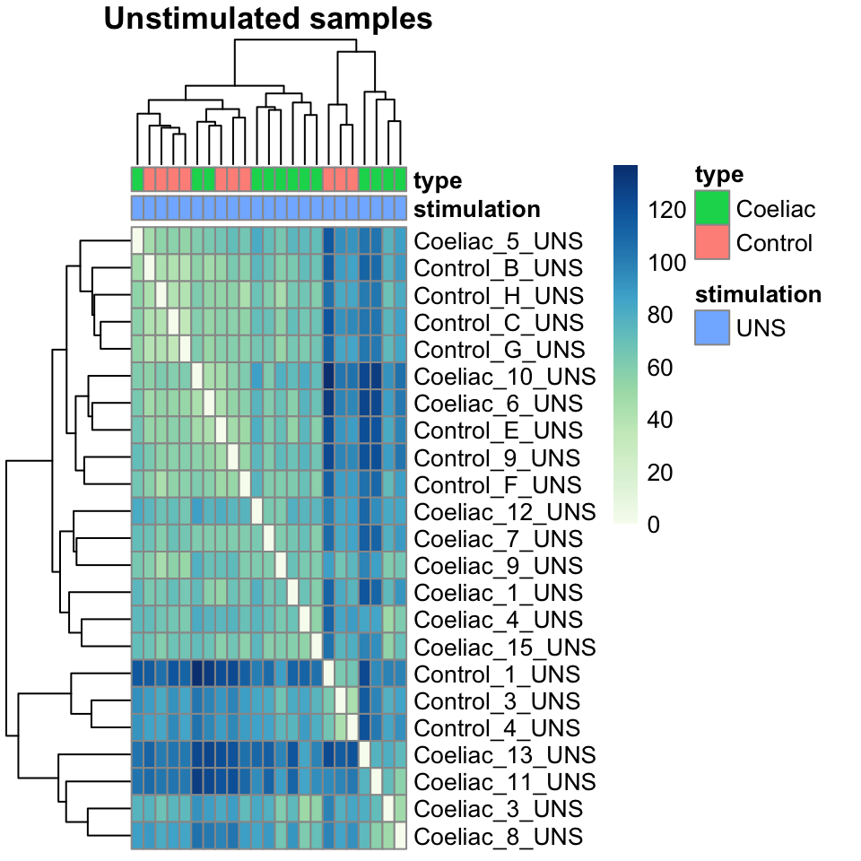

```r
library(RColorBrewer)
library(pheatmap)

# Again we need to transpose our matrix to then calculate the distance between each of the samples.
sampleDists <- dist(t(vst_unstim))
sampleDistMatrix <- as.matrix(sampleDists)

# By using brewer.pal() we can generate a palette of colors, for more colors check (http://colorbrewer2.org/)
colors <- colorRampPalette(brewer.pal(9, "GnBu"))(255)

pheatmap(sampleDistMatrix, main = "Unstimulated samples",
         show_colnames = FALSE,
         annotation = unstim_colData[,c("stimulation","type")],
         clustering_distance_rows=sampleDists,
         clustering_distance_cols=sampleDists,
         col=colors)
```

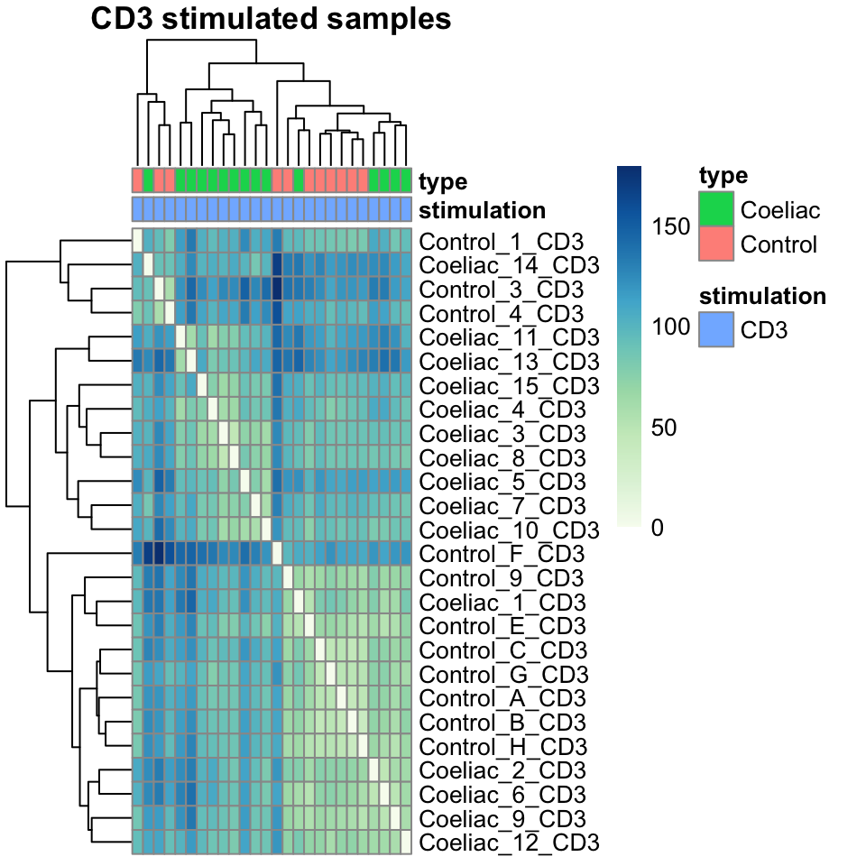

```r
########## Heatmap for CD3 samples
sampleDists <- dist(t(vst_cd3))
sampleDistMatrix <- as.matrix(sampleDists)

pheatmap(sampleDistMatrix, main = "CD3 stimulated samples",
         show_colnames = FALSE,
         annotation = cd3_colData[,c("stimulation","type")],
         clustering_distance_rows=sampleDists,
         clustering_distance_cols=sampleDists,
         col=colors)
```

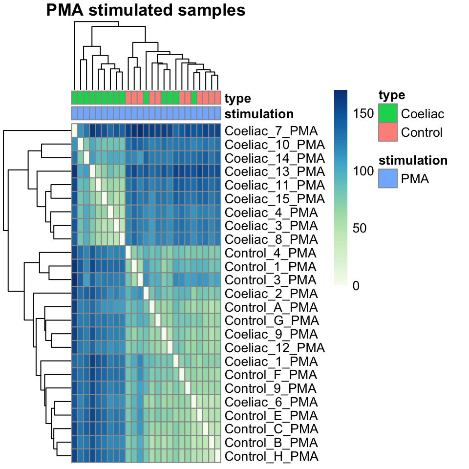

```r
########## Heatmap for PNA samples
sampleDists <- dist(t(vst_pma))
sampleDistMatrix <- as.matrix(sampleDists)

pheatmap(sampleDistMatrix, main = "PMA stimulated samples",
         show_colnames = FALSE,
         annotation = pma_colData[,c("stimulation","type")],
         clustering_distance_rows=sampleDists,
         clustering_distance_cols=sampleDists,
         col=colors)
```

# Q6: Compare the clustering of controls vs coeliac in the three conditions.

# Differential expression analysis

## Definition of differential expression

The definition of a differential expressed gene usually depends on whether or not a particular gene is significantly (p-value = 0.05, after multiple testing correction) over or under expressed when compared to another class (can be different treatment, control, tissue etc,). Nevertheless, we can be bit more strict in this definition, we could require either a lower p-value (such as 0.01, or 0.001), and require a certain difference of expression between the two conditions, this difference between two conditions can be interpreted as the log2 fold change ( log2(mean expression condition 1 / mean expression condition 2) ).

```r
# Load
library(DESeq2)
library(ggplot2)
library(ggsci)
library(ggrepel)

# To properly compare control versus celiac, we need to define that in our colData objects, therefore we need to set the colData$type as a factor, and the firs level should be control

unstim_colData$type <- factor(unstim_colData$type, levels= c("Control", "Coeliac"))
cd3_colData$type <- factor(cd3_colData$type, levels= c("Control", "Coeliac"))
pma_colData$type <- factor(pma_colData$type, levels= c("Control", "Coeliac"))

# We now generate the new DESeq objects and run the differential expression analysis.
dds_unstim <- DESeqDataSetFromMatrix(countData = unstim_countTable,
                              colData = unstim_colData,
                              design = ~ type)

dds_unstim <- DESeq(dds_unstim)
res_unstim <- results(dds_unstim)
head(res_unstim)
```

```
## log2 fold change (MAP): type Coeliac vs Control
## Wald test p-value: type Coeliac vs Control
## DataFrame with 6 rows and 6 columns
##               baseMean log2FoldChange     lfcSE       stat       pvalue
##              <numeric>      <numeric> <numeric>  <numeric>    <numeric>
## 1/2-SBSRNA4  18.970065    -0.04157449 0.2104567 -0.1975441 0.8434017767
## A1BG        184.208818     0.93438290 0.2574150  3.6298692 0.0002835649
## A1BG-AS1     32.846987    -0.24554189 0.2536913 -0.9678769 0.3331058725
## A1CF          3.446375    -0.72194777 0.2921516 -2.4711407 0.0134682820
## A2LD1        86.832573    -0.28977189 0.2652770 -1.0923370 0.2746850188
## A2M          69.562992    -0.29065099 0.2852553 -1.0189154 0.3082431190
##                   padj
##              <numeric>
## 1/2-SBSRNA4 0.96291065
## A1BG        0.02362755
## A1BG-AS1    0.73481606
## A1CF        0.18566157
## A2LD1       0.69336940
## A2M         0.72029628
```

```r
# Given the conditions we declared for differential expression analysis we can subset our list of
de_unstim <- res_unstim[which(res_unstim$padj <= 0.05),]
nrow(de_unstim)
```

[output not shown]

```r
dds_cd3 <- DESeqDataSetFromMatrix(countData = cd3_countTable,
                              colData = cd3_colData,
                              design = ~ type)
dds_cd3 <- DESeq(dds_cd3)
res_cd3 <- results(dds_cd3)
de_cd3 <- res_unstim [which(res_cd3$padj <= 0.05),]

dds_pma <- DESeqDataSetFromMatrix(countData = pma_countTable,
                              colData = pma_colData,
                              design = ~ type)
dds_pma <- DESeq(dds_pma)
res_pma <- results(dds_pma)
de_pma <- res_unstim [which(res_pma$padj <= 0.05),]
```

Q7: How many differentiall expressed genes did we find for CD3? And how many for PMA?

Let’s now make a Venn diagram to evaluate how many shared deferentially expressed genes we have between conditions.

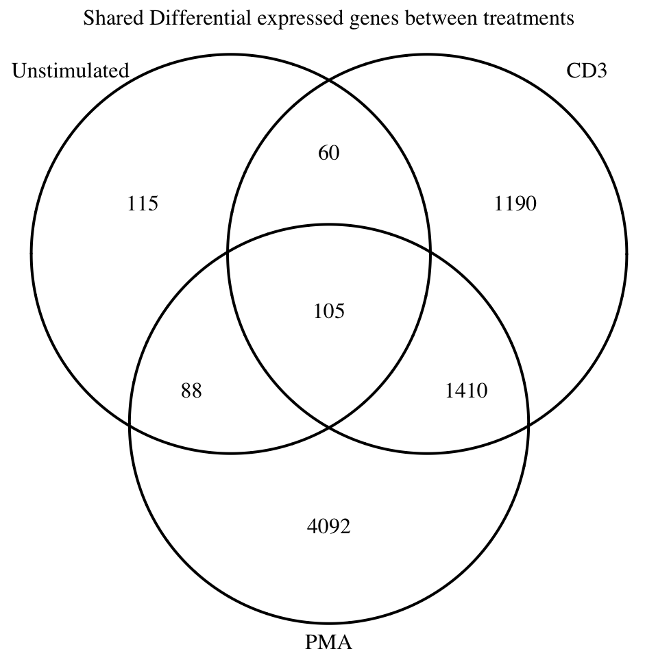

```r
library(VennDiagram)

DEG_list <- list(Unstimulated= rownames(de_unstim),
                 CD3=rownames(de_cd3),
                 PMA=rownames(de_pma)
                 )
vennDiagram <- venn.diagram(DEG_list,
                            filename = NULL,
                            main = "Shared Differential expressed genes between treatments"
                            )
plot.new()
grid.draw(vennDiagram)
```

## Printing your list of Differentially expressed genes

Printing and saving your list of deferentially expressed genes and it’s statistics is very convenient way to share your results.

```r
# Lets create a new directory to save our results
dir.create("./Results/")

# The write.csv function will generate an Excel "friendly" file.
unstim_fileName <- "./Results/diffExpGenes_unstim.csv"
write.csv(de_unstim, unstim_fileName)

cd3_fileName <- "./Results/diffExpGenes_cd3.csv"
write.csv(de_cd3, cd3_fileName)

pma_fileName <- "./Results/diffExpGenes_pma.csv"
write.csv(de_pma, pma_fileName)
```

## Visualization of Differentially expressed genes

### Volcano Plot

The volcano Plot is a great way to visualize your deferentially expressed genes. I will allow you to see towards which condition can differentiates the best between transcriptome.

By definition a volcano plot has in it’s X-axis the log2(fold change) per gene, whilst on the Y-axis the -log10(p Value) per gene. We already have all this information in our “res” objects from the DESeq2.

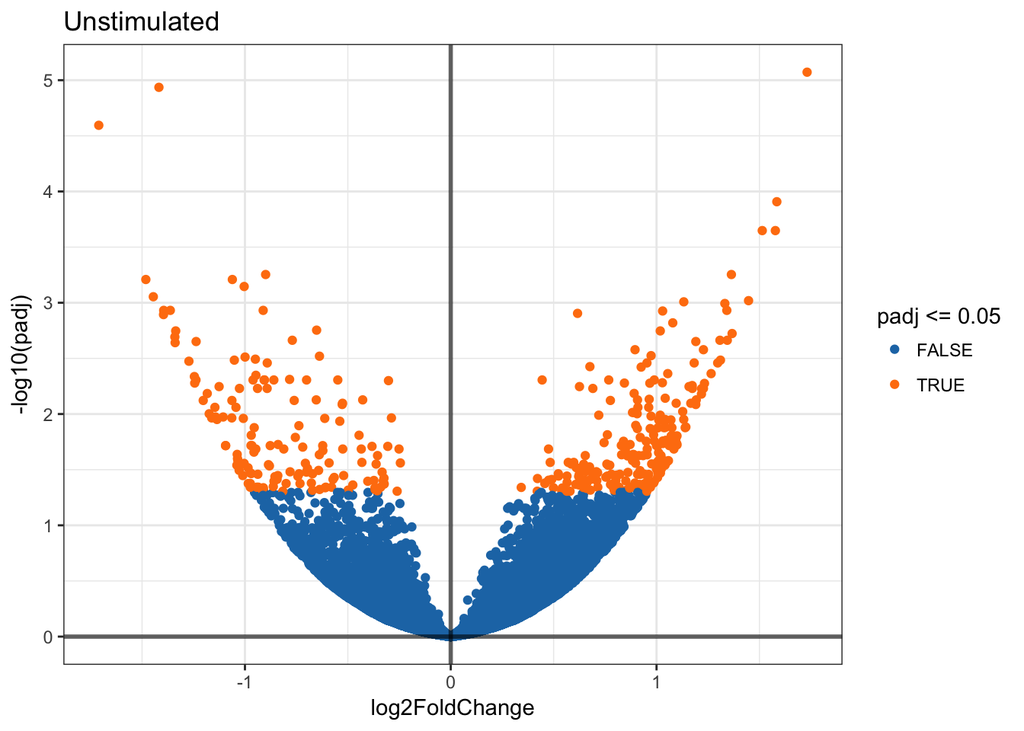

```r
library(gridExtra)

pData <- as.data.frame(res_unstim[which(!is.na(res_unstim$padj)),])
unstim_Volcano <- ggplot(pData, aes(x=log2FoldChange, y= -log10(padj)))+
                    geom_point(aes(color= padj <= 0.05))+
                    geom_hline(yintercept = 0, lwd=1, alpha= 0.6)+
                    geom_vline(xintercept = 0, lwd=1, alpha= 0.6)+
                    scale_color_d3()+
                    ggtitle("Unstimulated")+
                    theme_bw()

print(unstim_Volcano)
```

Lets also label the top 10 most deferentially significant genes, and generate the same plot for each of the comparisons.

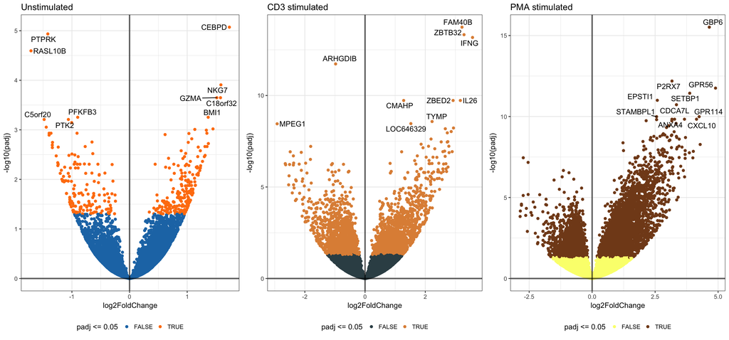

```r
pData$top10label <- NA
pData$top10label[order(pData$padj)[1:10]] <- rownames(pData)[order(pData$padj)[1:10]]
unstim_Volcano <- ggplot(pData, aes(x=log2FoldChange, y= -log10(padj)))+
                    geom_point(aes(color= padj <= 0.05))+
                    geom_hline(yintercept = 0, lwd=1, alpha= 0.6)+
                    geom_vline(xintercept = 0, lwd=1, alpha= 0.6)+
                    scale_color_d3()+
                    ggtitle("Unstimulated")+
                    geom_text_repel(aes(label=top10label))+ ##add the lables in the top 10
                    theme_bw()+
                    theme(legend.position = "bottom")

pData <- as.data.frame(res_cd3[which(!is.na(res_cd3$padj)),])
pData$top10label <- NA
pData$top10label[order(pData$padj)[1:10]] <- rownames(pData)[order(pData$padj)[1:10]]
cd3_Volcano <- ggplot(pData, aes(x=log2FoldChange, y= -log10(padj)))+
                    geom_point(aes(color= padj <= 0.05))+
                    geom_hline(yintercept = 0, lwd=1, alpha= 0.6)+
                    geom_vline(xintercept = 0, lwd=1, alpha= 0.6)+
                    scale_color_jama()+
                    geom_text_repel(aes(label=top10label))+ ##add the lables in the top 10
                    ggtitle("CD3 stimulated")+
                    theme_bw()+
                    theme(legend.position = "bottom")


pData <- as.data.frame(res_pma[which(!is.na(res_pma$padj)),])
pData$top10label <- NA
pData$top10label[order(pData$padj)[1:10]] <- rownames(pData)[order(pData$padj)[1:10]]
pma_Volcano <- ggplot(pData, aes(x=log2FoldChange, y= -log10(padj)))+
                    geom_point(aes(color= padj <= 0.05))+
                    geom_hline(yintercept = 0, lwd=1, alpha= 0.6)+
                    geom_vline(xintercept = 0, lwd=1, alpha= 0.6)+
                    scale_color_rickandmorty()+
                    geom_text_repel(aes(label=top10label))+ ##add the lables in the top 10
                    ggtitle("PMA stimulated")+
                    theme_bw()+
                    theme(legend.position = "bottom")

grid.arrange(unstim_Volcano, cd3_Volcano, pma_Volcano, nrow=1)
```

Q8: The PMA stimulated volcano plot has an enrichment of positive log2FoldChange genes. Are these genes higher or lower expressed in celial patients?

### Heatmap of differentially expressed genes

Heatmaps are color coded, graphical representations of a matrix. The rows and columns of this matrix can be arranged in a certain way to showcase the similarities between columns and rows. This arrangement of columns and rows can be using an unsupervised approach such as hierarchical clustering.

We firstly need normalize the expression levels to compare the expression levels between samples.

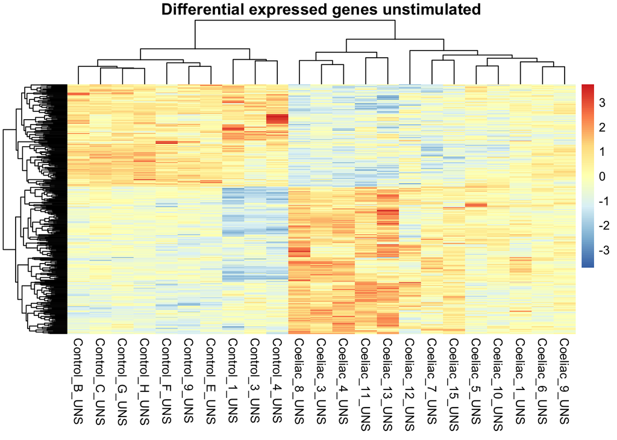

```r
library(pheatmap)

vst_unstim <- assay(vst(dds_unstim))
deGenes <- vst_unstim[rownames(de_unstim),]
pheatmap(deGenes, scale = "row",show_rownames = FALSE, main = "Differential expressed genes unstimulated")
```

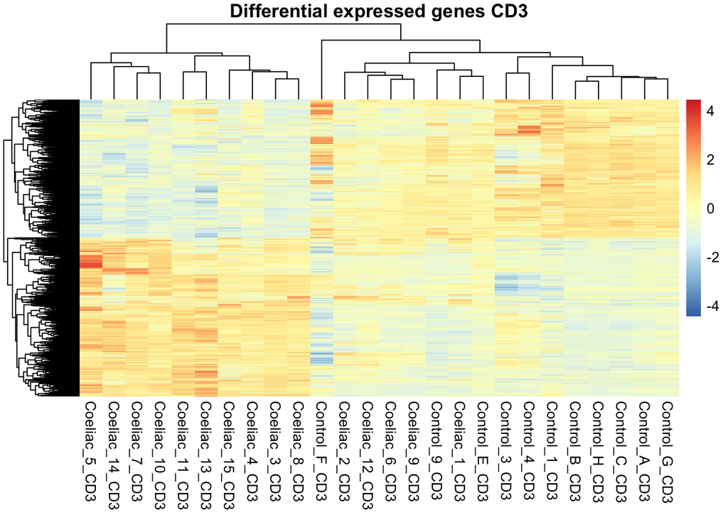

```r
vst_cd3 <- assay(vst(dds_cd3))
deGenes <- vst_cd3[rownames(de_cd3),]
pheatmap(deGenes, scale = "row",show_rownames = FALSE, main = "Differential expressed genes CD3")
```

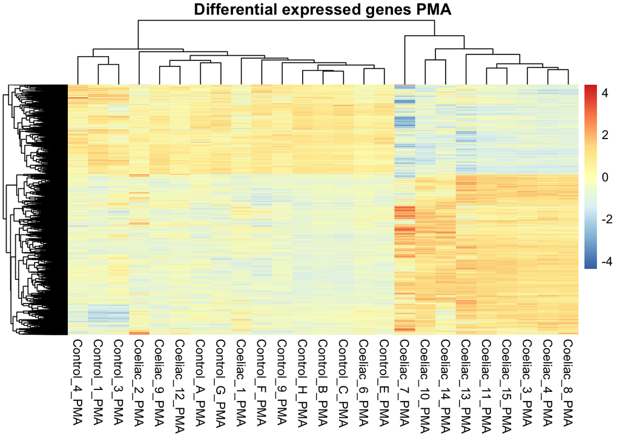

```r
vst_pma <- assay(vst(dds_pma))
deGenes <- vst_pma[rownames(de_pma),]
pheatmap(deGenes, scale = "row",show_rownames = FALSE, main = "Differential expressed genes PMA")
```

### Data points

In some cases it’s also useful to visualize a the expression values for a certain genes across all samples. Lets check for the top 10 most deferentially expressed genes between celiac and controls with no stimulation (“unstim” samples). Remember, in order to properly compare expression values across samples we need to use the normalized levels (in this case vst-transformed expression values)

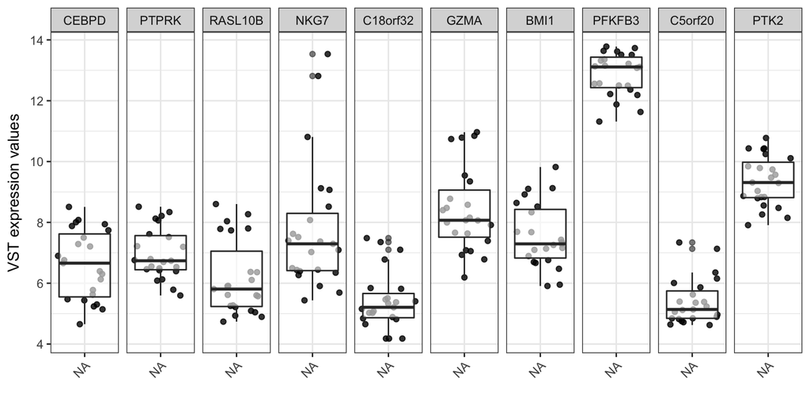

```r
library(reshape2)

top10Genes <- rownames(de_unstim)[order(de_unstim$padj)[1:10]]
# Using melt to literaly melt a wide data.frame into a long data.frame
pData <- melt(vst_unstim[top10Genes,])
# Add your sample information.
pData <- cbind(pData, unstim_colData[as.character(pData$Var2),])

top10_Plot <- ggplot(pData, aes(x= type, y= value))+
                geom_jitter(alpha=0.8)+
                geom_boxplot(alpha=0.6)+
                facet_grid(~Var1, scale="free")+
                ylab("VST expression values")+
                xlab("")+
                theme_bw()+
                theme(axis.text.x = element_text(angle=45, hjust = 1))
print(top10_Plot)
```

Q9: Look op the 'PTPRK' gene and its association with coealiac disease. Has this been reported in literature?

Also visualise the top 10 most deferentially expressed genes between celiac and controls for the CD3 stimulateed data and PMA stimulated data.

## Saving all complete Differentially expressed genes

```r
# The write.csv function will generate an Excel "friendly" file.
unstim_fileName <- "./Results/diffExpGenes_unstim_all.csv"
write.csv(res_unstim, unstim_fileName)

cd3_fileName <- "./Results/diffExpGenes_cd3_all.csv"
write.csv(res_cd3, cd3_fileName)

pma_fileName <- "./Results/diffExpGenes_pma_all.csv"
write.csv(res_pma, pma_fileName)
```